# 부스팅및

## Boosting Machine

- 부스팅 알고리즘은 여러 개의 약한 학습기를 순차적으로 학습-예측하면서 잘못 예측한 데이터에 가중치 부여를 통해 오류를 개선해 나가면서 학습하는 방식 #### 노란색 머신러닝교과서 with 파이썬 사이킷런, 텐서플로우 교재의 279쪽에 있음
- 부스팅의 대표적인 구현은 AdaBoost(Adaptive boosting)와 그래디언트 부스트가 있음.
- 에이다 부스트는 오류 데이터에 가중치를 부여하면서 부스팅을 수행하는 대표적인 알고리즘임

[figure not shown]

- https://ekdud7667.tistory.com/entry/Adaboost%EC%97%90%EC%9D%B4%EB%8B%A4%EB%B6%80%EC%8A%A4%ED%8A%B8
- https://injo.tistory.com/31

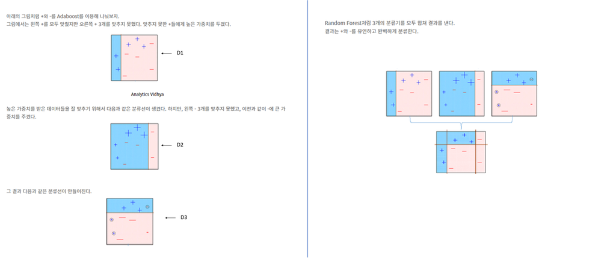

- GBM도 에이다부스트와 유사한, 가중치 업데이트를 경사 하강법을 이용하는 것이 차이이다.
- GBM은 분류와 회귀 모두 가능하다. 사이킷런에서는 GBM기반의 분류를 위하여 GradientBoostingClassifier 클래스를 제공한다.
- GBM은 과적합에도 강한 뛰어난 예측 성능을 가진 알고리즘이지만 수행시간이 오래 걸린다는 단점이 있다.
- GBM 기반의 ML 패키지에는 XGBoost와 LightGBM이 있다.

## [실습: 사용자 행동 인식 데이터 세트]

- UCI 머신러닝 리포지토리에서 제공하는 사용자 행동 데이터 세트에 대한 예측분류
- 30명에게 스마트폰 센서를 장착한뒤 사람의 동작과 관련된 여러가지 피처를 수집한 데이터임

```python
from sklearn.ensemble import GradientBoostingClassifier
import time
import warnings
warnings.filterwarnings('ignore')
```

```python
# https://pinkwink.kr/1252   (실습)


# GBM 하이퍼파라미터 튜닝: GridSearchCV 사용
#  - loss:경사하강법에 사용할 비용함수 지정
#  - learning_rage: GBM이 학습을 진행할때마다 적용되는 학습률, 0~1 사이값 지정가능하며 기본값은 1임
#  - n_estimators: weak learner의 개수, weak learner가 순차적으로 오류를 보정하므로
#             개수가 많을수록 에측 성능이 일정 수준까지 좋아질수 있음
#              개수가 많아질수록 시간이 오래걸림. 기본값 100
#  - subsample: weak learner가 학습에 사용하는 데이터의 샘플링 비율, 기본값은 1이며
#                전체 학습 데이터를 기반으로 학습한다는 의미임. (0.5이면 학습데이터의 50%)
#                과적합 우려가 있으면 1보다 작은값으로 설정
```

```python
# 에이다 부스트 실습은 아래 사이트에서 자료를 다운로드 받아 실습하세요
# https://injo.tistory.com/31  (실습코드)
```

```python
## 또는 머신러닝 교과서with 파이썬, 사이킷런, 텐서플로 교재(노란색) 279
```

## [XGBoost(eXtra Gradient Boost]

- 트리기반의 앙상블 학습에서 가장 각광받고 있는 알고리즘중 하나임
- GBM에 기반하고 있지만, GBM의 단점인 느린 수행 시간 및 과적합규제(Regularization) 부재 등의 문제를 해결한다.
- 특히 XGBoost는 병렬 CPU 환경에서 병렬 학습이 가능해 기존 GBM보다 빠르게 학습을 완료할 수 있다.
- 자체적으로 교차검증을 내장하고 있으며 결손값도 자체 처리가능하다.
- C++로 작성된 알고리즘으로
- 파이썬 자체에서 제공하는 xgboost, 사이킷런의 xgboost, 사이킷런과 호환되는 파이썬의 xgboost가 있다.
- 콘다 프롬프트 환경에서 인스톨함
- conda install -c anaconda py-xgboost
- 만약 위의 내용이 안된다면 https://www.lfd.uci.edu/~gohlke/pythonlibs/ 에서 xgboost로 검색하여서 다운로드한뒤
- 작업할 폴더로 이동하고(예: 콘다프롬프트에 나오는 경로가면 쉬움)
- 갓
- pip install 다운받은 파일이름으로 작업함.

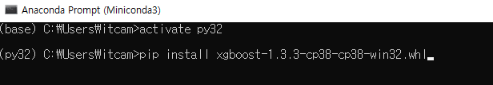

```python
# 파이썬 xgboost
import xgboost as xgb
print(xgb.__version__)


# 참고 사이킷런은
# from xgboost import XGBClassifier
```

```
1.3.3
```

### - 위스콘시 유방암 데이터 세트

- 종양의 크기, 모양등의 다양한 속성값을 기반으로 악성 종양(malignant:0인지
- 양성종양(benign:1)인지를 분류하는 데이터 세트,

```python
from xgboost import plot_importance #visualize features importnace
import pandas as pd
import numpy as np

from sklearn.datasets import load_breast_cancer
from sklearn.model_selection import train_test_split

import warnings
warnings.filterwarnings('ignore')

dataset = load_breast_cancer()
dataset
```

[output not shown]

```python
X_features = dataset.data
y_label = dataset.target
```

```python
cancer = pd.DataFrame(data = X_features, columns = dataset.feature_names)
cancer['target'] = y_label
cancer.head()
```

|  | mean radius | mean texture | mean perimeter | mean area | mean smoothness | mean compactness | mean concavity | mean concave points | mean symmetry | mean fractal dimension | ... | worst texture | worst perimeter | worst area | worst smoothness | worst compactness | worst concavity | worst concave points | worst symmetry | worst fractal dimension | target |
| --- | --- | --- | --- | --- | --- | --- | --- | --- | --- | --- | --- | --- | --- | --- | --- | --- | --- | --- | --- | --- | --- |
| 0 | 17.99 | 10.38 | 122.80 | 1001.0 | 0.11840 | 0.27760 | 0.3001 | 0.14710 | 0.2419 | 0.07871 | ... | 17.33 | 184.60 | 2019.0 | 0.1622 | 0.6656 | 0.7119 | 0.2654 | 0.4601 | 0.11890 | 0 |
| 1 | 20.57 | 17.77 | 132.90 | 1326.0 | 0.08474 | 0.07864 | 0.0869 | 0.07017 | 0.1812 | 0.05667 | ... | 23.41 | 158.80 | 1956.0 | 0.1238 | 0.1866 | 0.2416 | 0.1860 | 0.2750 | 0.08902 | 0 |
| 2 | 19.69 | 21.25 | 130.00 | 1203.0 | 0.10960 | 0.15990 | 0.1974 | 0.12790 | 0.2069 | 0.05999 | ... | 25.53 | 152.50 | 1709.0 | 0.1444 | 0.4245 | 0.4504 | 0.2430 | 0.3613 | 0.08758 | 0 |
| 3 | 11.42 | 20.38 | 77.58 | 386.1 | 0.14250 | 0.28390 | 0.2414 | 0.10520 | 0.2597 | 0.09744 | ... | 26.50 | 98.87 | 567.7 | 0.2098 | 0.8663 | 0.6869 | 0.2575 | 0.6638 | 0.17300 | 0 |
| 4 | 20.29 | 14.34 | 135.10 | 1297.0 | 0.10030 | 0.13280 | 0.1980 | 0.10430 | 0.1809 | 0.05883 | ... | 16.67 | 152.20 | 1575.0 | 0.1374 | 0.2050 | 0.4000 | 0.1625 | 0.2364 | 0.07678 | 0 |

5 rows × 31 columns

```python
cancer.describe()
```

|  | mean radius | mean texture | mean perimeter | mean area | mean smoothness | mean compactness | mean concavity | mean concave points | mean symmetry | mean fractal dimension | ... | worst texture | worst perimeter | worst area | worst smoothness | worst compactness | worst concavity | worst concave points | worst symmetry | worst fractal dimension | target |
| --- | --- | --- | --- | --- | --- | --- | --- | --- | --- | --- | --- | --- | --- | --- | --- | --- | --- | --- | --- | --- | --- |
| count | 569.000000 | 569.000000 | 569.000000 | 569.000000 | 569.000000 | 569.000000 | 569.000000 | 569.000000 | 569.000000 | 569.000000 | ... | 569.000000 | 569.000000 | 569.000000 | 569.000000 | 569.000000 | 569.000000 | 569.000000 | 569.000000 | 569.000000 | 569.000000 |
| mean | 14.127292 | 19.289649 | 91.969033 | 654.889104 | 0.096360 | 0.104341 | 0.088799 | 0.048919 | 0.181162 | 0.062798 | ... | 25.677223 | 107.261213 | 880.583128 | 0.132369 | 0.254265 | 0.272188 | 0.114606 | 0.290076 | 0.083946 | 0.627417 |
| std | 3.524049 | 4.301036 | 24.298981 | 351.914129 | 0.014064 | 0.052813 | 0.079720 | 0.038803 | 0.027414 | 0.007060 | ... | 6.146258 | 33.602542 | 569.356993 | 0.022832 | 0.157336 | 0.208624 | 0.065732 | 0.061867 | 0.018061 | 0.483918 |
| min | 6.981000 | 9.710000 | 43.790000 | 143.500000 | 0.052630 | 0.019380 | 0.000000 | 0.000000 | 0.106000 | 0.049960 | ... | 12.020000 | 50.410000 | 185.200000 | 0.071170 | 0.027290 | 0.000000 | 0.000000 | 0.156500 | 0.055040 | 0.000000 |
| 25% | 11.700000 | 16.170000 | 75.170000 | 420.300000 | 0.086370 | 0.064920 | 0.029560 | 0.020310 | 0.161900 | 0.057700 | ... | 21.080000 | 84.110000 | 515.300000 | 0.116600 | 0.147200 | 0.114500 | 0.064930 | 0.250400 | 0.071460 | 0.000000 |
| 50% | 13.370000 | 18.840000 | 86.240000 | 551.100000 | 0.095870 | 0.092630 | 0.061540 | 0.033500 | 0.179200 | 0.061540 | ... | 25.410000 | 97.660000 | 686.500000 | 0.131300 | 0.211900 | 0.226700 | 0.099930 | 0.282200 | 0.080040 | 1.000000 |
| 75% | 15.780000 | 21.800000 | 104.100000 | 782.700000 | 0.105300 | 0.130400 | 0.130700 | 0.074000 | 0.195700 | 0.066120 | ... | 29.720000 | 125.400000 | 1084.000000 | 0.146000 | 0.339100 | 0.382900 | 0.161400 | 0.317900 | 0.092080 | 1.000000 |
| max | 28.110000 | 39.280000 | 188.500000 | 2501.000000 | 0.163400 | 0.345400 | 0.426800 | 0.201200 | 0.304000 | 0.097440 | ... | 49.540000 | 251.200000 | 4254.000000 | 0.222600 | 1.058000 | 1.252000 | 0.291000 | 0.663800 | 0.207500 | 1.000000 |

8 rows × 31 columns

```python
#malignant : 0 / benign : 1
print(dataset.target_names)
print(cancer.target.value_counts())
```

```
['malignant' 'benign']
1    357
0    212
Name: target, dtype: int64
```

```python
X_train, X_test, y_train, y_test = train_test_split(X_features, y_label, test_size = 0.2, random_state = 156)
print('X_train shape : ',X_train.shape, 'X_test shape : ',X_test.shape)
```

```
X_train shape :  (455, 30) X_test shape :  (114, 30)
```

```python
# DMatrix: 넘파이 입력 파라미터를 받아서 만들어지는 XGBoost만의 전용 데이터 셋트
# Dmatrix의 주요 입력 파라미터는 data와 label,
# data는 피처 데이터 세트이며,
# label은 분류의 경우에는 레이블 데이터 세트,
# 회귀의 경우에는 숫자형인 종속값 데이터 세트
dtrain = xgb.DMatrix(data = X_train, label = y_train)
dtest = xgb.DMatrix(data = X_test, label = y_test)
print(type(dtrain))
```

```
<class 'xgboost.core.DMatrix'>
```

```python
params = {
    'max_depth' : 3,   #트리최대깊이

    # 학습율(사이킷런의 XGBClassifier를 사용할 경우 eta가 아니라 learning_rate임)
    'eta' : 0.1,
    'objective' : 'binary:logistic',   #이진함수
    'eval_metric' : 'logloss' #early_stopping을 하려면, 반드시 있어야 함  , 오류평가지표
}

num_rounds = 3000 # the number of boosting repetition
```

```python
# eval파라미터에 데이터세트를 작성해주면 평가를 eval에 있는 데이터 세트를 수행함
# https://injo.tistory.com/44?category=1068433

wlist = [(dtrain ,'train'), (dtest, 'eval')]
xgb_model = xgb.train(params=params, dtrain = dtrain,
                      num_boost_round=num_rounds,
                      evals = wlist,
                      verbose_eval=20,
                     early_stopping_rounds=100)
#evals : early_stopping을 하려면, 반드시 있어야 함
```

[output not shown]

```python
print('best iteration : ', xgb_model.best_iteration)
print('best score : ', xgb_model.best_score)
```

```
best iteration :  211
best score :  0.085593
```

```python
### predict: 예측
pred_prob = xgb_model.predict(dtest)
print(np.round(pred_prob[:10], 3))

# prob > 1 : 1 or prob <= 1: 0
pred = [1 if x > 0.5 else 0 for x in pred_prob]
print(pred[:10])
```

```
[0.934 0.003 0.91  0.094 0.993 1.    1.    0.999 0.997 0.   ]
[1, 0, 1, 0, 1, 1, 1, 1, 1, 0]
```

```python
from sklearn.metrics import accuracy_score
from sklearn.metrics import recall_score
from sklearn.metrics import precision_score

from sklearn.metrics import confusion_matrix

print('accuracy : {0:.4f} precision : {1:.4f} recall : {2:.4f}'.format(accuracy_score(y_test, pred),
                                                                       precision_score(y_test, pred),
                                                                       recall_score(y_test, pred)
                                                                  ))
print(confusion_matrix(y_test, pred))
# 정확도, 정밀도, 재현율
```

```
accuracy : 0.9737 precision : 0.9744 recall : 0.9870
[[35  2]
 [ 1 76]]
```

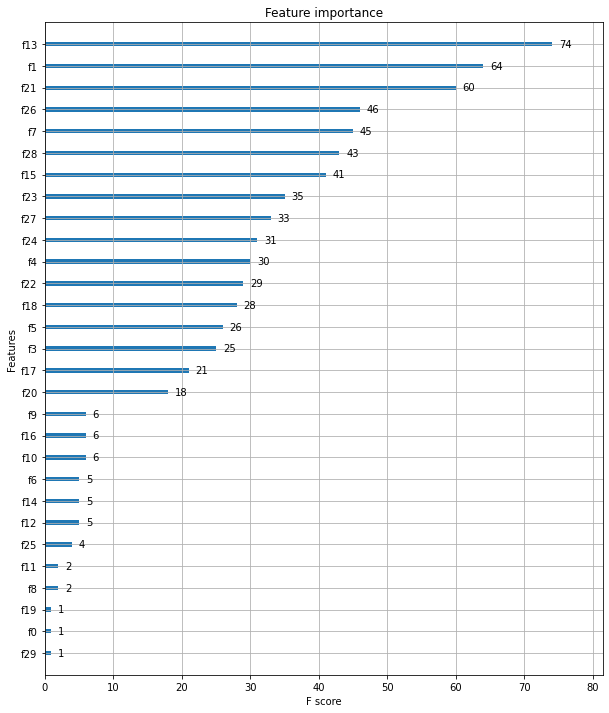

```python
from xgboost import plot_importance
import matplotlib.pyplot as plt

fig, ax = plt.subplots(figsize = (10,12))
plot_importance(xgb_model, ax = ax)

# 출력되는 f1,f2는 피처1,2 로 변수명(순서별로)
```

```python
# 파이썬의 XGBoost는 사이킷런의 GridSearchCV와 유사하게 데이터 세트에 대한 교차 검증 수행후 최적의 파라미터를 구할수 있는 방법을 cv() API로 제공함.
# params(dict): 부스터 파라미터
# dtrain(Dmatrix): 학습데이터
# num_boost_round(int): 부스팅 반복 횟수
# nfold(int): CV 폴드개수
# stratified(bool): CV수행시 층화 표본 추출(stratified sampling) 수행여부
# metrics(string or list of strings): CV 수행시 모니터링할 성능 평가 지표
# early_stopping_rounds(int): 조기 중단을 화성화시킴. 바복횟수 지정

params
```

```
{'max_depth': 3,
 'eta': 0.1,
 'objective': 'binary:logistic',
 'eval_metric': 'logloss'}
```

```python
xgb.cv(params, dtrain, num_boost_round=10, nfold = 3, stratified=False, folds = None)
```

|  | train-logloss-mean | train-logloss-std | test-logloss-mean | test-logloss-std |
| --- | --- | --- | --- | --- |
| 0 | 0.610037 | 0.000064 | 0.617448 | 0.004962 |
| 1 | 0.541817 | 0.000202 | 0.555140 | 0.008989 |
| 2 | 0.483716 | 0.000955 | 0.503529 | 0.012238 |
| 3 | 0.434676 | 0.001311 | 0.459869 | 0.015795 |
| 4 | 0.392310 | 0.001686 | 0.423058 | 0.016789 |
| 5 | 0.355129 | 0.001390 | 0.391187 | 0.019785 |
| 6 | 0.322530 | 0.001909 | 0.361120 | 0.019378 |
| 7 | 0.294159 | 0.001618 | 0.337139 | 0.021085 |
| 8 | 0.269083 | 0.002068 | 0.314902 | 0.019971 |
| 9 | 0.246208 | 0.001940 | 0.295012 | 0.019237 |

```python
xgb_model.best_score
```

```
0.085593
```